# Assignment 5A: Airline Delays

Kenny Jeannite

2026-10-03

# Introduction

For this assignment, I am working with a small table of arrival delays for two airlines, Alaska and AM West, across five cities. The table is in a “wide” format, where each city is its own column and the airline name is only written once for every two rows. The goal is to tidy the data into a long format and then compare how often each airline is delayed, both overall and city by city.

The main question I want to answer is: which airline has the better on-time performance, and does the answer change depending on whether I look at the cities separately or all together?

# Loading the Data

I recreated the table from the assignment as a CSV file in the same format. The values are padded with spaces so the columns line up, so I use `strip.white = TRUE` to trim them; otherwise ” delayed” would not match “delayed” later on. The airline name is left blank on the “delayed” rows and there is an empty row between the two airlines, just like the original. I uploaded the file to my GitHub repo so it can be read from anywhere.

```r
data_source <- "https://raw.githubusercontent.com/kjeannite/data-607/refs/heads/master/assignment-5a/airlines.csv"

airlines_raw <- read.csv(data_source, check.names = FALSE, na.strings = "", strip.white = TRUE)

airlines_raw
```

```
##                   Los Angeles Phoenix San Diego San Francisco Seattle
## 1  ALASKA on time         497     221       212           503    1841
## 2    <NA> delayed          62      12        20           102     305
## 3    <NA>    <NA>          NA      NA        NA            NA      NA
## 4 AM WEST on time         694    4840       383           320     201
## 5    <NA> delayed         117     415        65           129      61
```

# Filling in the Missing Data

The first two columns do not have names, so I am naming them `airline` and `status`. Then I remove the empty row between the two airlines. The airline name is missing on every “delayed” row, so I use `fill()` to copy the airline name down from the row above.

```r
names(airlines_raw)[1:2] <- c("airline", "status")

airlines <- airlines_raw %>%
  filter(!if_all(everything(), is.na)) %>%
  fill(airline, .direction = "down")

airlines
```

```
##   airline  status Los Angeles Phoenix San Diego San Francisco Seattle
## 1  ALASKA on time         497     221       212           503    1841
## 2  ALASKA delayed          62      12        20           102     305
## 3 AM WEST on time         694    4840       383           320     201
## 4 AM WEST delayed         117     415        65           129      61
```

# Wide to Long

Here I am changing the data so each row has one airline, one status, one city and the number of flights. This makes it much easier to group and summarize.

```r
airlines_long <- airlines %>%
  pivot_longer(cols = -c(airline, status),
               names_to = "city",
               values_to = "flights")

head(airlines_long, 10)
```

```
## # A tibble: 10 × 4
##    airline status  city          flights
##    <chr>   <chr>   <chr>           <int>
##  1 ALASKA  on time Los Angeles       497
##  2 ALASKA  on time Phoenix           221
##  3 ALASKA  on time San Diego         212
##  4 ALASKA  on time San Francisco     503
##  5 ALASKA  on time Seattle          1841
##  6 ALASKA  delayed Los Angeles        62
##  7 ALASKA  delayed Phoenix            12
##  8 ALASKA  delayed San Diego          20
##  9 ALASKA  delayed San Francisco     102
## 10 ALASKA  delayed Seattle           305
```

There are 20 rows now (2 airlines x 2 statuses x 5 cities), and 11,000 flights in total.

# Overall Comparison

First I am adding up all of the flights for each airline and calculating the percentage that were delayed. I am using percentages instead of counts because AM West has almost twice as many flights as Alaska, so comparing the counts alone would not be fair.

```r
overall <- airlines_long %>%
  group_by(airline) %>%
  summarise(
    total_flights = sum(flights),
    delayed = sum(flights[status == "delayed"]),
    delay_pct = round(100 * delayed / total_flights, 1)
  )

overall
```

```
## # A tibble: 2 × 4
##   airline total_flights delayed delay_pct
##   <chr>           <int>   <int>     <dbl>
## 1 ALASKA           3775     501      13.3
## 2 AM WEST          7225     787      10.9
```

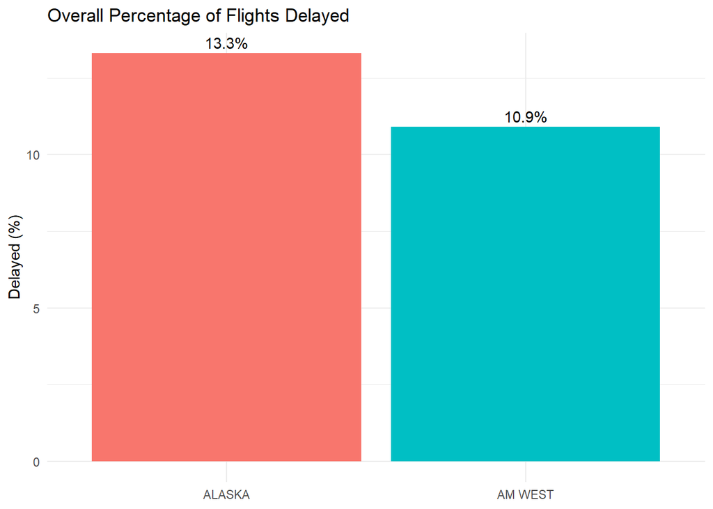

```r
ggplot(overall, aes(x = airline, y = delay_pct, fill = airline)) +
  geom_col() +
  geom_text(aes(label = paste0(delay_pct, "%")), vjust = -0.4) +
  labs(title = "Overall Percentage of Flights Delayed",
       x = NULL, y = "Delayed (%)") +
  theme_minimal() +
  theme(legend.position = "none")
```

Overall, Alaska had 13.3% of its flights delayed and AM West had 10.9%. Looking only at the totals, AM West seems like the more reliable airline.

# City by City Comparison

Next I am doing the same calculation for each city.

```r
by_city <- airlines_long %>%
  group_by(airline, city) %>%
  summarise(
    total_flights = sum(flights),
    delayed = sum(flights[status == "delayed"]),
    delay_pct = round(100 * delayed / total_flights, 1),
    .groups = "drop"
  )

by_city %>%
  select(city, airline, delay_pct) %>%
  pivot_wider(names_from = airline, values_from = delay_pct)
```

```
## # A tibble: 5 × 3
##   city          ALASKA `AM WEST`
##   <chr>          <dbl>     <dbl>
## 1 Los Angeles     11.1      14.4
## 2 Phoenix          5.2       7.9
## 3 San Diego        8.6      14.5
## 4 San Francisco   16.9      28.7
## 5 Seattle         14.2      23.3
```

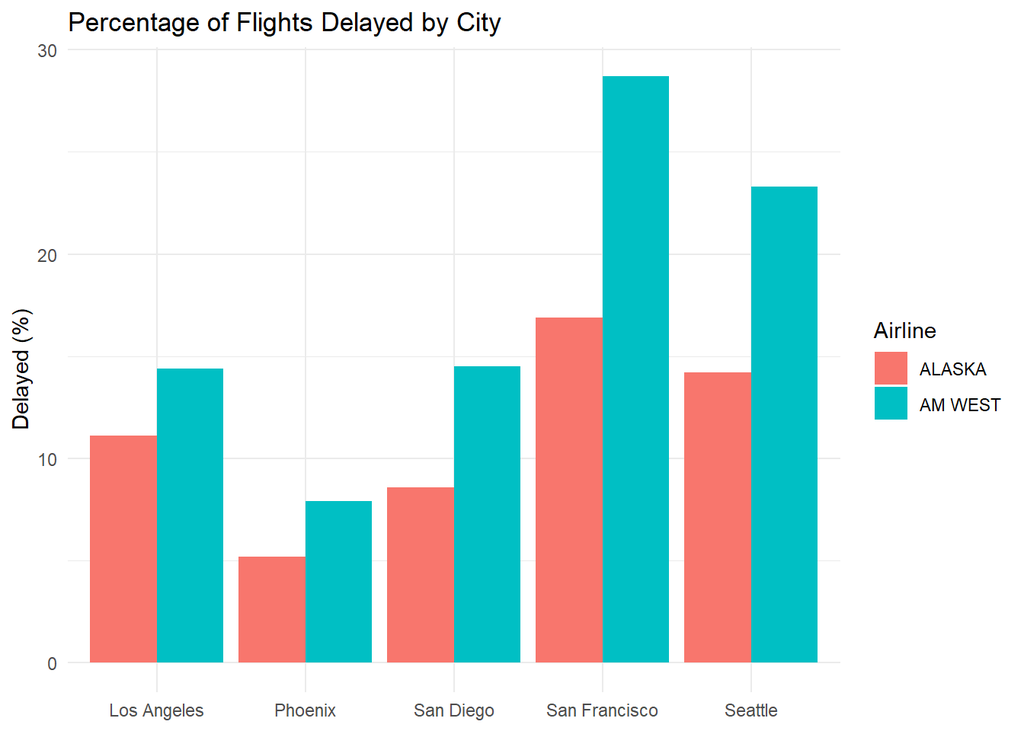

```r
ggplot(by_city, aes(x = city, y = delay_pct, fill = airline)) +
  geom_col(position = "dodge") +
  labs(title = "Percentage of Flights Delayed by City",
       x = NULL, y = "Delayed (%)", fill = "Airline") +
  theme_minimal()
```

When I look at the cities one at a time, Alaska has a lower delay percentage than AM West in all five cities. The biggest gap is in San Francisco, where Alaska was delayed 16.9% of the time compared to 28.7% for AM West.

# Why the Results Disagree

This is the strange part. Alaska is better in every single city, but AM West is better overall. At first that did not make sense to me, so I looked at where each airline’s flights actually go.

```r
flight_share <- by_city %>%
  group_by(airline) %>%
  mutate(share_of_flights = round(100 * total_flights / sum(total_flights), 1)) %>%
  ungroup() %>%
  select(airline, city, total_flights, share_of_flights, delay_pct) %>%
  arrange(airline, desc(share_of_flights))

flight_share
```

```
## # A tibble: 10 × 5
##    airline city          total_flights share_of_flights delay_pct
##    <chr>   <chr>                 <int>            <dbl>     <dbl>
##  1 ALASKA  Seattle                2146             56.8      14.2
##  2 ALASKA  San Francisco           605             16        16.9
##  3 ALASKA  Los Angeles             559             14.8      11.1
##  4 ALASKA  Phoenix                 233              6.2       5.2
##  5 ALASKA  San Diego               232              6.1       8.6
##  6 AM WEST Phoenix                5255             72.7       7.9
##  7 AM WEST Los Angeles             811             11.2      14.4
##  8 AM WEST San Diego               448              6.2      14.5
##  9 AM WEST San Francisco           449              6.2      28.7
## 10 AM WEST Seattle                 262              3.6      23.3
```

Most of AM West’s flights (about 72.7%) are in Phoenix, which has the lowest delay rates of any city for both airlines. Most of Alaska’s flights (about 56.8%) are in Seattle, which has a much higher delay rate. So the overall percentage is not really comparing the airlines to each other. It is mostly comparing Phoenix to Seattle.

Since each airline’s overall number is a weighted average of its city numbers, the airline with most of its flights in the “easy” city ends up looking better overall, even though it does worse in each city.

# Conclusion

Tidying this data was mostly about dealing with the blank cells. Once the airline names were filled in and the cities were turned into rows, the summaries only took a few lines of code.

The bigger lesson was in the analysis. If I only looked at the overall numbers, I would say AM West is the better airline. But city by city, Alaska is better everywhere. The city is what is driving the difference, so I think the city-by-city comparison is the fairer one. If I were choosing an airline for a trip to one of these cities, I would pick Alaska. One limitation is that the data only says whether a flight was delayed and not how long the delay was, so I cannot tell which airline has worse delays when they do happen.